# Data Analyst Job Postings Report

Workshop 3

May 27, 2026

## Introduction

This report uses a sample of **402** U.S. data analyst job postings. Each row includes a **median salary estimate** (USD), a **minimum years of experience** requirement (numeric where extraction succeeded), and a **data languages** label (`R`, `Python`, `Both`, or `Neither`) indicating whether the posting explicitly calls for R, Python, both, or neither.

The sample is useful for exploring patterns, but it is **not a census of the job market**. Many postings lack salary or experience fields, labels were assigned automatically and may be imperfect, and **402 observations** limit how strongly we can generalize. The plots below should be read as descriptive summaries of this dataset, not definitive market facts.

## Experience and Salary

### Introduction

The scatter plot below compares **minimum years of experience** (horizontal axis) with **median salary estimate** (vertical axis) for postings where both values are available (**309** of **402** rows). Each point is one job posting. A smoother line is included only to highlight the general direction of the cloud; it is not a formal regression model.

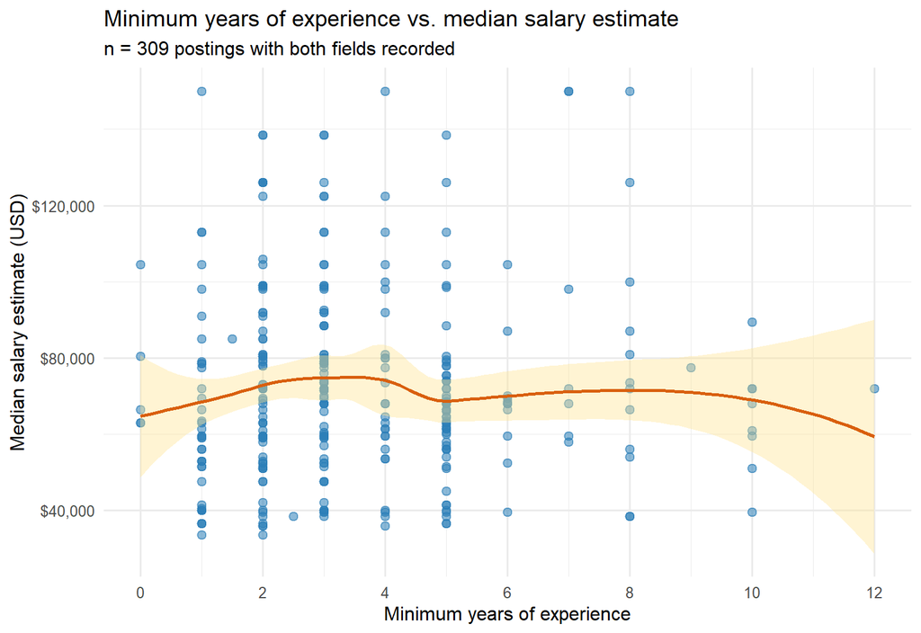

### Interpretation

**Limitations:** Only **309** postings appear in this plot; **93** are dropped because salary or experience is missing or non-numeric. Experience was parsed from text and may be wrong for some rows. With a modest sample, a few outliers can pull the smoother line; correlation does not imply causation (employers may pay more for skills and sector, not years alone).

## Salary by Data Languages

### Introduction

The box plot summarizes the **distribution of median salary estimates** within each **data languages** category. The box shows the middle 50% of salaries (interquartile range); the line inside is the median; whiskers extend to typical range; points are individual postings. Categories with few postings produce unstable boxes.

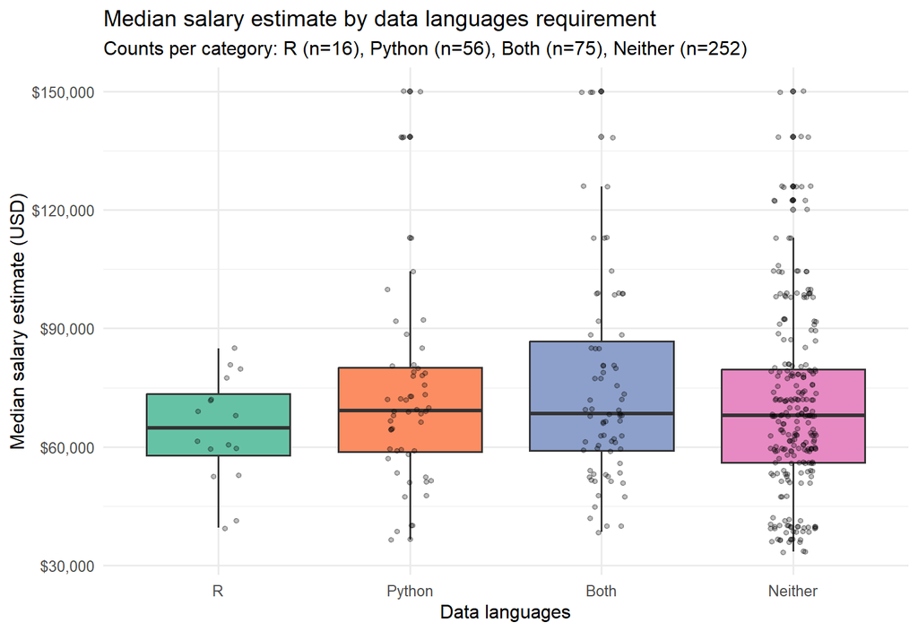

### Interpretation

**Neither** is the largest group in this sample and spans a wide salary range, from entry-level to six figures—consistent with many analyst roles not naming R or Python in structured fields. **Python** and **Both** postings often sit at similar or somewhat higher medians than **R** alone, though overlaps are large and medians should be compared cautiously.

## Personal Reflection

The use of AI simplifies the process of querying data and generating plots. With the right prompts, AI can generate code that is efficient and easy to understand. However, it is important to note that the AI is not always accurate and it is important to verify the results.